# Practical Machine Learning Course Project

21 Sep 2014

Let’s read the training data and look what is inside.

```r
library(caret)
train=read.csv('pml-training.csv')
summary(train$classe)
head(train)
```

[output not shown]

Our problem is to predict the values of train$classe based on other variables. In this dataset we can find a variable X, which completely describes the prediction. The following plot proves that:

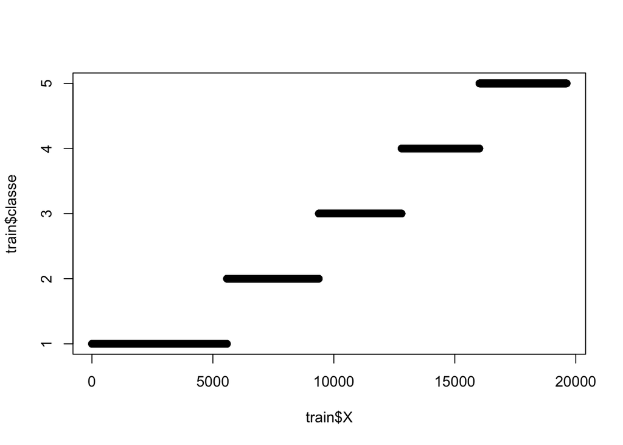

```r
plot(train$X, train$classe)
```

But it is actually the wrong dependence: X is just a number of the row, and the dataset is sorted by classe. However, one cannot be completely sure! :)

In the dataset there are many missing (NA) values, and also string values, which I don’t want to include now in the classification because I don’t have time, and it’s always good to process what is simple and then improve the model adding more details. Let’s remove all NA-containing columns:

```r
nonnacols=colSums(is.na(train))==0
train=train[,nonnacols]
```

Let’s partition data

```r
trainIndex = createDataPartition(train$classe,p=0.7,list=FALSE)
training = train[trainIndex,-1]
testing = train[trainIndex,-1]
```

The first column is X, which spoils all the prediction :) Also, to simplify the problem, let’s consider the numeric columns only

```r
nums <- sapply(training, is.numeric)
numtraining=training[,nums]
numtesting=testing[,nums]
```

I tried using PCA but it didn’t help me a lot with efficiency… It’s very simple to apply different algorithms with caret package, but applies cross-validation automatically and takes time. Unfortunately I started this work too late to try that… So I use randomForest package

```r
library(randomForest)
fit <- randomForest(training$classe ~ .,   data=numtraining)
print(fit) # view results
```

```
##
## Call:
##  randomForest(formula = training$classe ~ ., data = numtraining)
##                Type of random forest: classification
##                      Number of trees: 500
## No. of variables tried at each split: 7
##
##         OOB estimate of  error rate: 0.13%
## Confusion matrix:
##      A    B    C    D    E class.error
## A 3906    0    0    0    0   0.0000000
## B    2 2656    0    0    0   0.0007524
## C    0    3 2390    3    0   0.0025042
## D    0    0    7 2243    2   0.0039964
## E    0    0    0    1 2524   0.0003960
```

```r
importance(fit) # importance of each predictor
```

```
##                      MeanDecreaseGini
## raw_timestamp_part_1          1355.97
## raw_timestamp_part_2            14.37
## num_window                     792.37
## roll_belt                      715.37
## pitch_belt                     416.59
## yaw_belt                       514.31
## total_accel_belt               154.55
## gyros_belt_x                    52.49
## gyros_belt_y                    65.92
## gyros_belt_z                   187.25
## accel_belt_x                    76.35
## accel_belt_y                    84.83
## accel_belt_z                   238.71
## magnet_belt_x                  146.70
## magnet_belt_y                  240.83
## magnet_belt_z                  221.60
## roll_arm                       183.35
## pitch_arm                       87.01
## yaw_arm                        118.13
## total_accel_arm                 47.00
## gyros_arm_x                     59.21
## gyros_arm_y                     59.72
## gyros_arm_z                     26.74
## accel_arm_x                    132.74
## accel_arm_y                     80.00
## accel_arm_z                     57.40
## magnet_arm_x                   128.21
## magnet_arm_y                   105.22
## magnet_arm_z                    81.48
## roll_dumbbell                  242.72
## pitch_dumbbell                 104.74
## yaw_dumbbell                   155.05
## total_accel_dumbbell           168.14
## gyros_dumbbell_x                57.22
## gyros_dumbbell_y               125.82
## gyros_dumbbell_z                34.32
## accel_dumbbell_x               157.38
## accel_dumbbell_y               242.21
## accel_dumbbell_z               195.80
## magnet_dumbbell_x              284.48
## magnet_dumbbell_y              405.36
## magnet_dumbbell_z              452.76
## roll_forearm                   346.25
## pitch_forearm                  483.89
## yaw_forearm                     83.49
## total_accel_forearm             45.53
## gyros_forearm_x                 34.53
## gyros_forearm_y                 53.86
## gyros_forearm_z                 32.30
## accel_forearm_x                178.82
## accel_forearm_y                 63.40
## accel_forearm_z                121.44
## magnet_forearm_x               105.40
## magnet_forearm_y               105.08
## magnet_forearm_z               135.61
```

```r
confusionMatrix(testing$classe, predict(fit, testing))
```

```
## Confusion Matrix and Statistics
##
##           Reference
## Prediction    A    B    C    D    E
##          A 3906    0    0    0    0
##          B    0 2658    0    0    0
##          C    0    0 2396    0    0
##          D    0    0    0 2252    0
##          E    0    0    0    0 2525
##
## Overall Statistics
##
##                Accuracy : 1
##                  95% CI : (1, 1)
##     No Information Rate : 0.284
##     P-Value [Acc > NIR] : <2e-16
##
##                   Kappa : 1
##  Mcnemar's Test P-Value : NA
##
## Statistics by Class:
##
##                      Class: A Class: B Class: C Class: D Class: E
## Sensitivity             1.000    1.000    1.000    1.000    1.000
## Specificity             1.000    1.000    1.000    1.000    1.000
## Pos Pred Value          1.000    1.000    1.000    1.000    1.000
## Neg Pred Value          1.000    1.000    1.000    1.000    1.000
## Prevalence              0.284    0.193    0.174    0.164    0.184
## Detection Rate          0.284    0.193    0.174    0.164    0.184
## Detection Prevalence    0.284    0.193    0.174    0.164    0.184
## Balanced Accuracy       1.000    1.000    1.000    1.000    1.000
```

```r
test=read.csv('pml-testing.csv')
nonnacols=colSums(is.na(test))==0
test=test[,nonnacols]
nums <- sapply(test, is.numeric)
test=test[,nums]
predict(fit, test)
```

```
##  1  2  3  4  5  6  7  8  9 10 11 12 13 14 15 16 17 18 19 20
##  B  A  B  A  A  E  D  B  A  A  B  C  B  A  E  E  A  B  B  B
## Levels: A B C D E
```

Thank you for your attention.